# Solow model

Kenji Sato

微分方程式のシミュレーションの基本を習得できれば，ソローモデルの分析は簡単にできる。

可視化のために **ggplot2** パッケージを使おう。インストールしていない場合は `install.packages("ggplot2")` を実行してインストールすること。

```r
library(ggplot2)
```

ソローモデルのパラメータは，

- 貯蓄率 $s$
- 資本減耗率 $\delta$
- 技術成長率 $g$
- 人口成長率 $n$
- 生産関数 $f$

であった。ここでは生産関数をコブ・ダグラス型 $f(k) = k^\alpha$ を仮定しよう。したがって，$f$ の代わりに

- 資本分配率 $\alpha$

を決めれば $f$ が定まる。次のようにパラメータを特定化しよう。

```r
alpha <- 0.3
delta <- 0.05
g <- 0.02
n <- 0.01
s <- 0.4
```

分析開始時点の効率労働あたりの資本（初期条件）`k0` を以下の通り決める。

```r
k0 <- 0.1
```

生産関数

$$f(k) = k^\alpha$$

```r
prod_func <- function(k)　k ^ alpha
```

生産関数のグラフは次のような形状をしている。

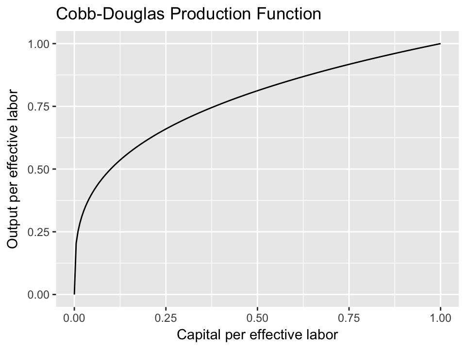

```r
kgrid <- seq(from = 0, to = 1.0, length.out = 200)

qplot(x = kgrid, y = prod_func(kgrid), geom = 'line') +
  labs(x = "Capital per effective labor", y = "Output per effective labor",
       title = "Cobb-Douglas Production Function")
```

微分方程式のシミュレーションに必要なパラメータ：

```r
dt <- 0.01   # controls precision of approximation
t_max <- 100 # simulation for t_max years
```

ソローモデルの微分方程式

$$\dot k(t) = sf(k(t)) - (\delta + g + n)k(t)$$
… とその離散時間近似

$$\frac{k(t+\Delta t) - k(t)}{\Delta t} = sf(k(t)) - (\delta + g + n) k(t)$$

少し変形すると次の漸化式を得る。

$$k(t+\Delta t)
= k(t) + \Delta t \left[
sf(k(t)) - (\delta + g + n) k(t)
\right]$$

それではコードを書いてみよう。次の関数は，$k(t)$ から $k(t+\Delta t)$ を計算するコードである。

```r
solow_update <- function(k){
  k + dt * (s * prod_func(k) - (delta + g + n) * k)
}
```

この関数を繰り返し適用すれば，ソローモデルのシミュレーションが実行できる。

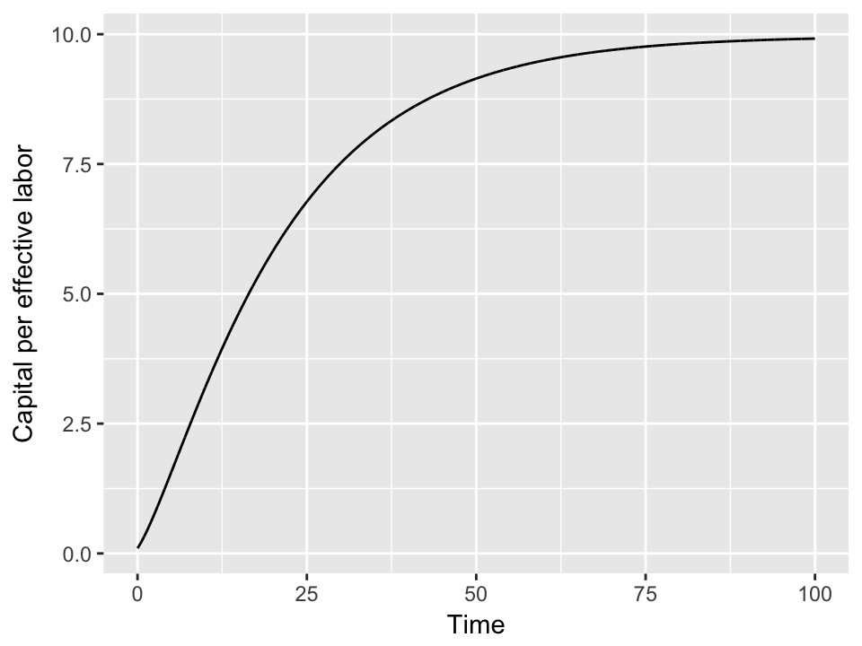

```r
t <- seq(from = 0, to = t_max, by = dt)   # 評価する時刻
simulation <- as.data.frame(t)            # 結果を記録するデータフレーム
simulation$k <- numeric(length(t))        # 資本ストック用のコラムを増やす

simulation$k[1] <- k0
for (i in 2:nrow(simulation)){
  simulation$k[i] <- solow_update(simulation$k[i-1])
}

ggplot(simulation, aes(x = t, y = k)) +
  geom_line() + labs(x = "Time", y = "Capital per effective labor")
```

効率労働あたりの資本が収束していくことを確認できるだろう。この値は次の方程式をとけば解析的に計算できる。

$$0 = s f(k) - (g + n + \delta) k$$

解は次の式で与えられる。

$$k^* = \left(\frac{s}{g + n + \delta}\right)^{\frac{1}{1 - \alpha}}$$

実際にこの値に収束しているかを見ておこう。

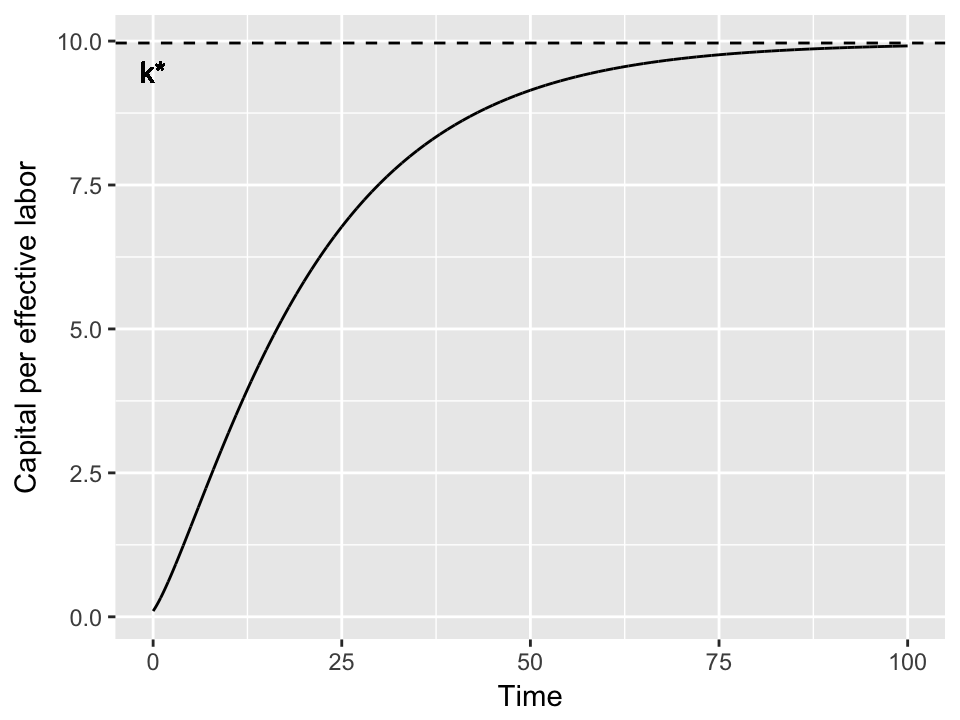

```r
kstar = (s / (g + n + delta))^(1 / (1 - alpha))

ggplot(simulation, aes(x = t, y = k)) +
  geom_line() + labs(x = "Time", y = "Capital per effective labor") +
  geom_hline(yintercept = kstar, linetype = "dashed") +
  geom_text(x = 0, y = 0.95 * kstar, label = "k*")
```

## 練習問題

1. $k(0) > k^*$ なる $k(0)$ を選んで同じシミュレーションを実行し，$k(t)$ が $k^*$ に収束する様子を図示しなさい。
2. $k(t)$ を計算できれば，$Y(t) = A(t)L(t)f(k(t))$, $C(t)/L(t) = (1-s)A(t)f(k(t))$ などの重要なマクロ変数のシミュレーションが実行できる。 $Y(t)$, $C(t)/L(t)$ の時間を通じた変化を計算し，図示しなさい。